# Worked Example: Arthritis

Johan Larsson

Behnaz Pirzamanbein

Jonas Wallin

# 1 Arthritis

In this worked example, we will be working with data from a double-blind clinical trial comparing a new treatment for rheumatoid arthritis with a placebo. The outcome records whether patients showed no, some, or marked improvement. The [dataset documentation](https://search.r-project.org/CRAN/refmans/vcd/html/Arthritis.html) does not name the specific treatment.

The data comes from the [vcd package](https://CRAN.R-project.org/package=vcd). To begin, let’s load the package and take a `glimpse()` at the data.

```r
# install.packages("vcd") # if you haven't installed it yet
library(vcd)
library(tidyverse)

glimpse(Arthritis)
```

```
## Rows: 84
## Columns: 5
## $ ID        <int> 57, 46, 77, 17, 36, 23, 75, 39, 33, 55, 30, 5, 63, 83, 66, 4…
## $ Treatment <fct> Treated, Treated, Treated, Treated, Treated, Treated, Treate…
## $ Sex       <fct> Male, Male, Male, Male, Male, Male, Male, Male, Male, Male, …
## $ Age       <int> 27, 29, 30, 32, 46, 58, 59, 59, 63, 63, 64, 64, 69, 70, 23, …
## $ Improved  <ord> Some, None, None, Marked, Marked, Marked, None, Marked, None…
```

Notice that `Improved` is helpfully formatted as an ordinal (ordered) variable already, which is going to help ggplot to choose the correct color palettes for us.

# 2 Bar Charts

Let’s start with a simple bar chart to see how many people were allocated to the two treatment arms.

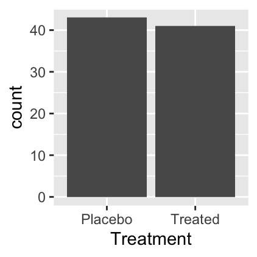

```r
library(tidyverse)

ggplot(Arthritis, aes(Treatment)) +
  geom_bar()
```

## 2.1 Was the Treatment Effective?

Now for something more interesting. Let’s try to look at how well the treatment seems to have worked. We start with a stacked bar chart.

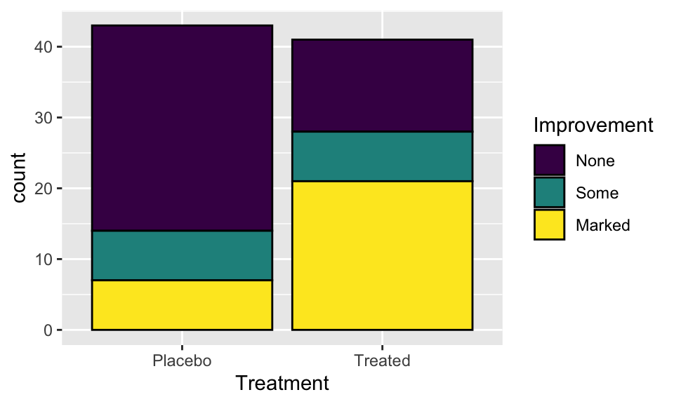

```r
ggplot(Arthritis, aes(x = Treatment, fill = Improved)) +
  geom_bar(color = "black") +
  labs(fill = "Improvement") # add a better legend title
```

It’s immediately clear that the treatment has worked well! The count of people with an improvement is much higher in the treatment arm compared with the placebo arm. But how do the treatments compare in terms of people who’ve made *some* improvement? This is difficult to say from our approach here. This is due to two reasons:

1. The stacked bar chart makes it hard to compare all but the bottom segment (`Marked` here), since the other portions of the bars are not aligned.[^1]
2. The bars are not proportional.[^2]

Let’s try a grouped proportional bar chart instead. To achieve this, we need to do a little preparatory work, since ggplot2 does not offer a direct option for this purpose.

What we need to do is to prepare a data set with the proportions that we would like to plot. In the following lines, we

1. use `count()` to count the number of observations in each combination of `Treatment` and `Improved`,
2. group the data set by `Treatment`, and
3. compute the proportions using `mutate()`.

```r
arthritis_prop <-
  Arthritis %>%
  count(Treatment, Improved) %>% # like group_by + summarize
  group_by(Treatment) %>%
  mutate(prop = n / sum(n))
```

Now, we’re ready to construct our plot. This will be done similarly to a standard grouped bar plot, except we will use `geom_col()` and map the `y` aesthetic, as we are working with summary data.

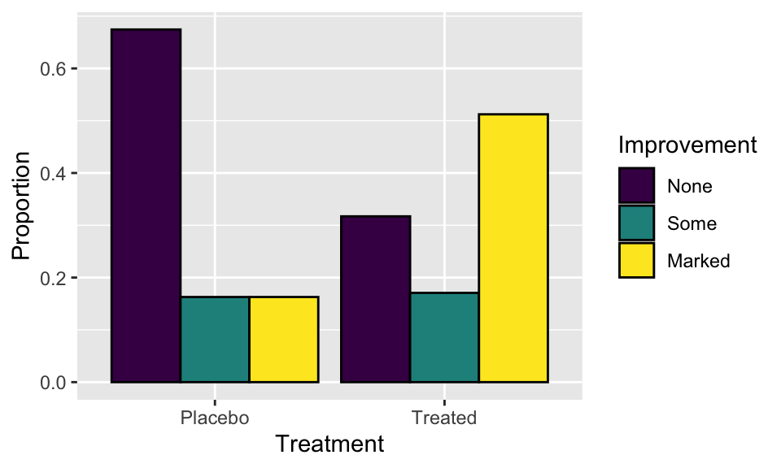

```r
ggplot(arthritis_prop, aes(Treatment, prop, fill = Improved)) +
  geom_col(color = "black", position = "dodge") +
  labs(fill = "Improvement", y = "Proportion")
```

Now, it becomes quite easy to compare the proportion of people who showed some improvement between the two groups.

See if you can also create a proportional stacked bar chart and compare the result with your previous charts.

## 2.2 A Larger Example with Unequal Groups

Both problems are more visible in `DanishWelfare`, also supplied by **vcd**. We will compare place of residence (`Urban`) across marital-status groups (`Status`). The [dataset](https://search.r-project.org/CRAN/refmans/vcd/html/DanishWelfare.html) already contains frequencies in `Freq`, so we sum those counts. We also give the categories more readable labels using `fct_recode()` from **forcats**, which is loaded with **tidyverse**. This function renames factor levels using `new_label = "old_label"`. For example, `Widowed = "Widow"` changes the label `"Widow"` to `"Widowed"`. The category counts and factor order are preserved.

```r
welfare_summarized <-
  DanishWelfare %>%
  group_by(Status, Urban) %>%
  summarize(Count = sum(Freq), .groups = "drop") %>%
  mutate(
    Status = fct_recode(Status, Widowed = "Widow"),
    Urban = fct_recode(Urban,
                       "Copenhagen suburbs" = "SubCopenhagen",
                       "Large cities" = "LargeCity",
                       "Other cities" = "City",
                       "Countryside" = "Country")
  )

welfare_prop <-
  welfare_summarized %>%
  group_by(Status) %>%
  mutate(prop = Count / sum(Count))

# Keep the same residence colors in the bar charts, mosaic, and waffles.
welfare_colors <- c("Copenhagen" = "darkorange",
                    "Copenhagen suburbs" = "skyblue",
                    "Large cities" = "goldenrod",
                    "Other cities" = "seagreen",
                    "Countryside" = "orchid")
```

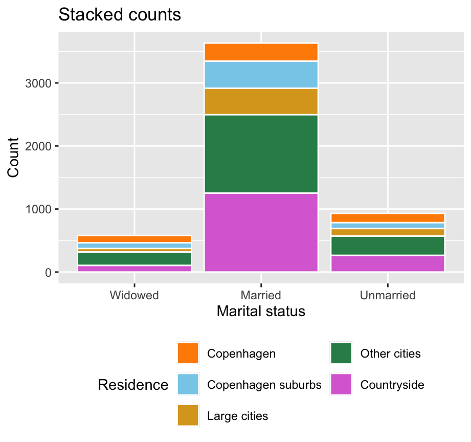

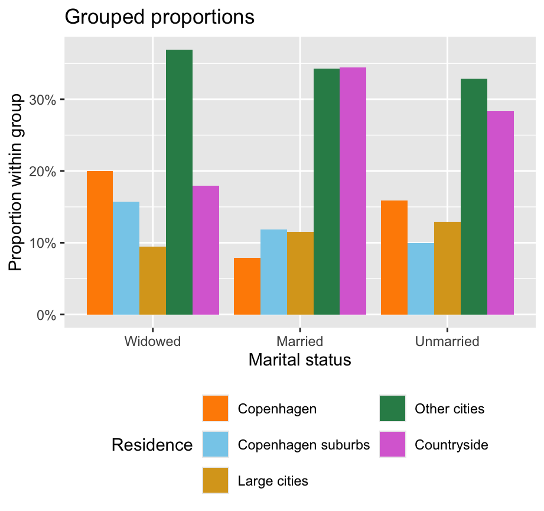

```r
ggplot(welfare_prop, aes(Status, Count, fill = Urban)) +
  geom_col(color = "white") +
  scale_fill_manual(values = welfare_colors) +
  guides(fill = guide_legend(nrow = 3)) +
  theme(legend.position = "bottom") +
  labs(title = "Stacked counts", x = "Marital status",
       y = "Count", fill = "Residence")

ggplot(welfare_prop, aes(Status, prop, fill = Urban)) +
  geom_col(position = "dodge") +
  scale_y_continuous(labels = scales::label_percent()) +
  scale_fill_manual(values = welfare_colors) +
  guides(fill = guide_legend(nrow = 3)) +
  theme(legend.position = "bottom") +
  labs(title = "Grouped proportions", x = "Marital status",
       y = "Proportion within group", fill = "Residence")
```

The groups contain 580 widowed, 3,633 married, and 931 unmarried respondents. With five colored segments and such different totals, the floating segments are harder to compare. For example, the married group has **more Copenhagen residents** than the widowed group (288 versus 116), but Copenhagen represents a **smaller proportion** of that group (7.9% versus 20%). The grouped proportional chart makes both the denominator and the common baseline clear.

# 3 Mosaic Plots

In the lecture, we also encountered mosaic plots. These extend proportional stacked bar charts by allowing the widths of the bars to vary with the relative group sizes. We’ll use the **ggmosaic2** package here.

```r
# install.packages("ggmosaic2") # if you don't already have the package

library(ggmosaic2)
```

**ggmosaic2** works directly with a ggplot2 object, adding auxiliary functions (`geom_*()` functions) to extend its functionality.

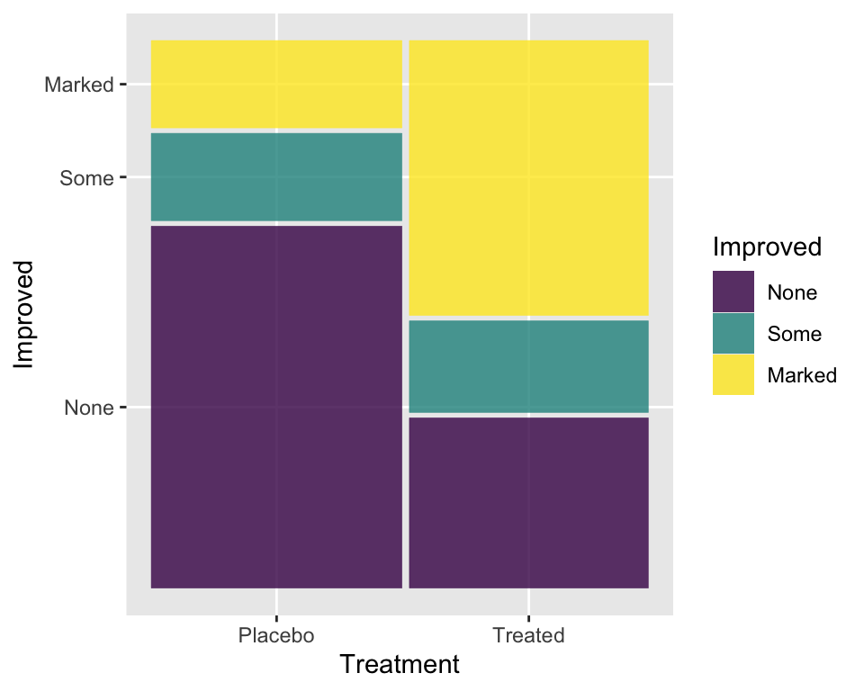

```r
ggplot(Arthritis) +
  geom_mosaic(aes(x = product(Improved, Treatment), fill = Improved))
```

The key features to notice about this call are

1. that we supply the `aes()` mapping to `geom_mosaic()` in this example, with `fill = Improved` determining the colors, and
2. the call to `product(Improved, Treatment)`, which lists the variables from the inner subdivision to the outer grouping. With the default layout, `Treatment` determines the widths of the bars, and `Improved` subdivides each bar vertically.

Read the dimensions of this plot as follows:

- The **width** of each treatment bar represents that arm’s share of all participants.
- The **height** of each colored segment represents the proportion of participants in that improvement category *within that treatment arm*.
- The **area** of each rectangle is proportional to the share of all participants with that combination of treatment and improvement.

For example, 21 of the 41 treated participants showed `Marked` improvement. The height of their segment therefore represents `21 / 41`, while its area represents `21 / 84`, since there are 84 participants in total.

The mosaic plot therefore shows both the relative sizes of the treatment arms and their improvement proportions in a single plot.[^3]

Try switching the order to `product(Treatment, Improved)`. Which variable now determines the widths? What proportions do the vertical subdivisions show? Which ordering makes it easier to compare improvement between treatment arms?

## 3.1 A Mosaic Plot for the Danish Welfare Data

The unequal group sizes in `DanishWelfare` are more visible in a mosaic plot. We reuse `welfare_summarized` and its residence colors. Since each row contains an aggregated count, `weight = Count` makes the rectangles represent respondents rather than rows in the summary table.

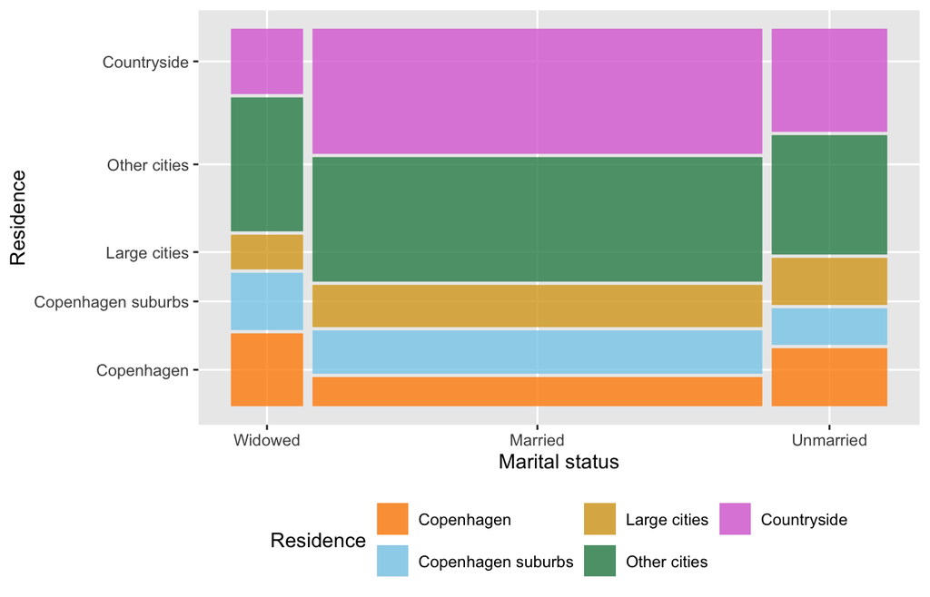

```r
ggplot(welfare_summarized) +
  geom_mosaic(aes(x = product(Urban, Status), fill = Urban, weight = Count)) +
  scale_fill_manual(values = welfare_colors) +
  guides(fill = guide_legend(nrow = 2)) +
  theme(legend.position = "bottom") +
  labs(x = "Marital status", y = "Residence", fill = "Residence")
```

The widths represent the marital-status group sizes, while the segment heights represent residence proportions within each group. For example, the married group is much wider, but its Copenhagen segment is shorter than that of the widowed group (7.9% versus 20%). Its Copenhagen rectangle still has a larger area because it represents more respondents (288 versus 116). The mosaic therefore displays both group size and composition, although the interior segments still lack a common baseline for comparing their heights.

# 4 Waffle Plots

Waffle plots are easy-to-read visualizations that, while quite uncommon in statistical visualizations, are much more prevalent in media outlets such as newspapers. As we mentioned in the lecture, they are at their best when some of the categories are so small that their sizes are hard to estimate in a bar chart or mosaic plot.

For this example, install **waffle** from [GitHub](https://github.com/hrbrmstr/waffle) using the **remotes** package. Run these installation commands once before continuing.

```r
#install.packages("remotes") # if you haven't already installed it
library(remotes)
#remotes::install_github("hrbrmstr/waffle")
```

For a count waffle, we first need the number of participants in each category. Group the data by `Improved` and `Treatment`, then use `summarize()` together with `n()` to compute the counts. Before looking at the following code, see if you can do this by yourself. The result should be a 6-row tibble with columns `Treatment`, `Improved` and `Count` (or whatever you want to call it). Save the result to an object called `arthritis_summarized`.

```r
arthritis_summarized <-
  Arthritis %>%
  group_by(Treatment, Improved) %>%
  summarize(Count = n())
head(arthritis_summarized)
```

```
## # A tibble: 6 × 3
## # Groups:   Treatment [2]
##   Treatment Improved Count
##   <fct>     <ord>    <int>
## 1 Placebo   None        29
## 2 Placebo   Some         7
## 3 Placebo   Marked       7
## 4 Treated   None        13
## 5 Treated   Some         7
## 6 Treated   Marked      21
```

Now we’re ready to start making waffles! The aesthetics you need to know about here are `fill` and `values`. Mapping `Count` to `values` means that **one square represents one participant**, while `fill = Improved` determines the colors. We start with the simplest possible waffle chart, just looking at improvement among the participants in the treatment arm.

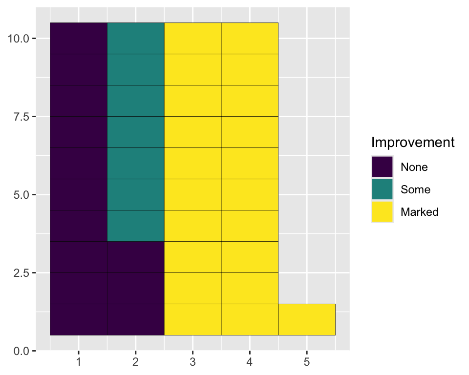

```r
library(waffle)

filter(arthritis_summarized, Treatment == "Treated") %>%
  ggplot(aes(fill = Improved, values = Count)) +
  geom_waffle() +
  labs(fill = "Improvement")
```

The treated group contains 13 participants with `None`, 7 with `Some`, and 21 with `Marked` improvement. The plot therefore has 41 squares. Each square represents `100 / 41` percent, or about 2.44% of the treated group.

This looks kind of like a waffle chart, but there’s a lot of superfluous information that we’d rather get rid of. Thankfully, **waffle** provides the helpful `theme_enhance_waffle()` function for this. Moreover, we probably prefer the symbols (rectangles) to be squares — it’s supposed to look like a waffle after all, right? — which we can accomplish by forcing the coordinate system to be isometric using `coord_equal()`. Finally, I think it looks more aesthetically pleasing if we swap the black line color for white, increase their widths slightly, and change theme to the minimal variant.

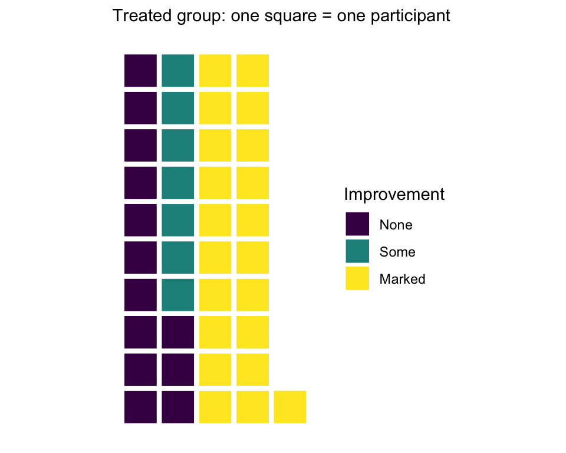

```r
filter(arthritis_summarized, Treatment == "Treated") %>%
  ggplot(aes(fill = Improved, values = Count)) +
  geom_waffle(color = "white", size = 1.5) +
  coord_equal() +
  theme_minimal() +
  theme_enhance_waffle() +
  labs(fill = "Improvement",
       subtitle = "Treated group: one square = one participant")
```

This looks much better, doesn’t it?

To be able to use waffle charts to see both of the treatment arms at once, we need to use something called **facets**, which we haven’t covered in the course yet. If you already know about facets, however, feel free to modify the plot now by faceting on the type of treatment.

## 4.1 Counts and Percentages with More Data

Let’s return to `DanishWelfare` and select the **3,633 married respondents**. A count waffle needs one square for each respondent. A percentage waffle uses 100 squares for the whole group, so one square represents 1%.

```r
welfare_married <-
  welfare_summarized %>%
  filter(Status == "Married") %>%
  mutate(Percent = 100 * Count / sum(Count),
         Squares = round(Percent))

welfare_married
```

```
## # A tibble: 5 × 5
##   Status  Urban              Count Percent Squares
##   <fct>   <fct>              <dbl>   <dbl>   <dbl>
## 1 Married Copenhagen           288    7.93       8
## 2 Married Copenhagen suburbs   430   11.8       12
## 3 Married Large cities         419   11.5       12
## 4 Married Other cities        1245   34.3       34
## 5 Married Countryside         1251   34.4       34
```

```r
#sum(welfare_married$Squares)
```

Here, rounding gives 8, 12, 12, 34, and 34 percentage squares, which sum to 100. Check this sum when using other data: ordinary rounding does not always give exactly 100 squares. We use 60 squares per full row for the count waffle and a 10-by-10 grid for the percentage waffle. `flip = TRUE` fills the rows horizontally.

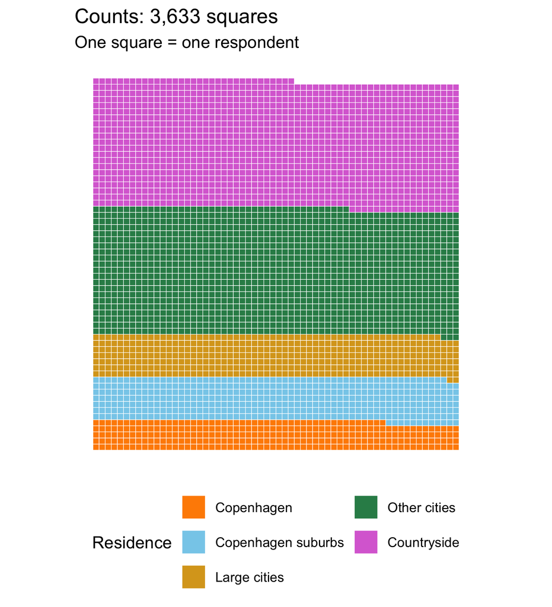

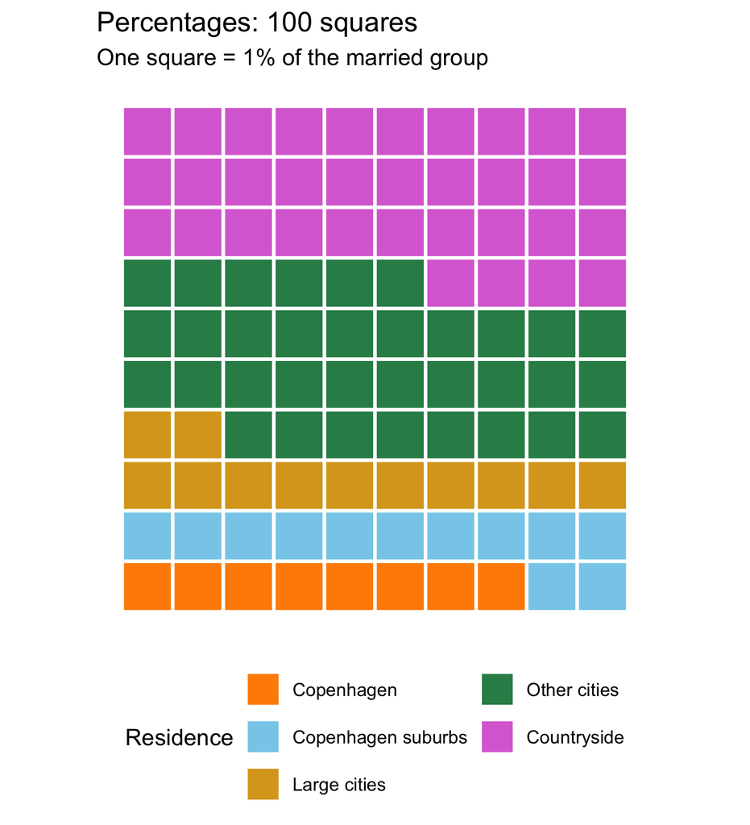

```r
welfare_count_plot <-
  ggplot(welfare_married, aes(fill = Urban, values = Count)) +
  geom_waffle(n_rows = 60, flip = TRUE, color = "white", size = 0.15) +
  coord_equal() +
  scale_fill_manual(values = welfare_colors) +
  guides(fill = guide_legend(nrow = 3)) +
  theme_minimal() +
  theme_enhance_waffle() +
  theme(legend.position = "bottom") +
  labs(title = "Counts: 3,633 squares", fill = "Residence",
       subtitle = "One square = one respondent")

welfare_percent_plot <-
  ggplot(welfare_married, aes(fill = Urban, values = Squares)) +
  geom_waffle(n_rows = 10, flip = TRUE, color = "white", size = 0.8) +
  coord_equal() +
  scale_fill_manual(values = welfare_colors) +
  guides(fill = guide_legend(nrow = 3)) +
  theme_minimal() +
  theme_enhance_waffle() +
  theme(legend.position = "bottom") +
  labs(title = "Percentages: 100 squares", fill = "Residence",
       subtitle = "One square = 1% of the married group")

welfare_count_plot
welfare_percent_plot
```

The count waffle preserves every respondent, but the many small squares make it dense. The percentage waffle makes the composition easier to read, at the cost of rounding. For example, 430 respondents from Copenhagen suburbs and 419 from large cities both become 12 percentage squares.

## 4.2 Comparing Three Groups

Now show count waffles for all three marital-status groups. `facet_wrap(~ Status)` gives each group its own panel. With fixed scales and the same number of squares per full row, squares have the same size in every panel.

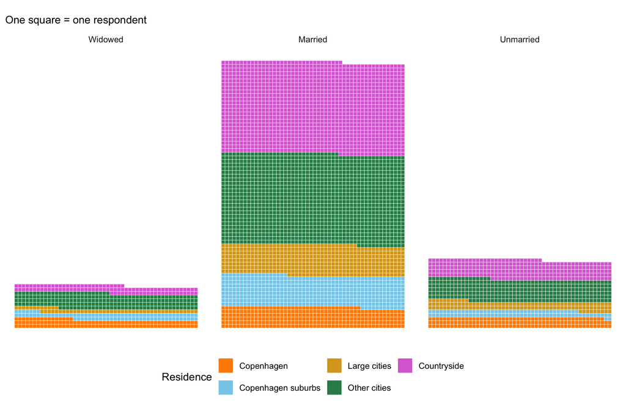

```r
welfare_groups_plot <-
  ggplot(welfare_summarized, aes(fill = Urban, values = Count)) +
  geom_waffle(n_rows = 50, flip = TRUE, color = "white", size = 0.15) +
  facet_wrap(~ Status, nrow = 1) +
  coord_equal() +
  scale_fill_manual(values = welfare_colors) +
  guides(fill = guide_legend(nrow = 2)) +
  theme_minimal() +
  theme_enhance_waffle() +
  theme(legend.position = "bottom") +
  labs(fill = "Residence", subtitle = "One square = one respondent")

welfare_groups_plot
```

The interpretation issues remain. The married group has a larger waffle because it has more respondents, and its 288 Copenhagen squares still correspond to a smaller share than the 116 Copenhagen squares in the widowed group. The other colored regions begin at different positions, making their sizes harder to compare. Percentage waffles would adjust for group size, but grouped proportional bars also give every category a common baseline.

# 5 Source Code

The source code for this document is available at https://github.com/stat-lu/dataviz/blob/main/worked-examples/arthritis.Rmd.

[^1]: This is not quite as severe a problem for this particular visualization since the inner grouping variable is ordinal. For other problems, however, this can be much more detrimental to the result.
[^2]: To be fair, the differences between the group sizes are small here, but this also means that we don’t lose much information when using proportional bars instead.
[^3]: These are relative sizes. To communicate the actual sample sizes, also provide the counts in the text.